# Trabalho final - planejamento de experimentos

Elias Ribeiro, Ornella Scardua e Lucas Lacerda

20/03/2022

# Importação da base de dados

```r
(dados <- readr::read_table("Tree_throughfall.txt")[,1:11])
```

```
## # A tibble: 2,100 × 11
##    Date  Pluviometer  Plot Distance  Tree    sp  tree number rainfall rainfall_1
##    <chr> <chr>       <dbl>    <dbl> <dbl> <dbl> <dbl>  <dbl>    <dbl>      <dbl>
##  1 26/0… P58             1      100     1     5  5.97      2     3.52       2.42
##  2 26/0… P59             1      100     1     5  5.97      2     2.4        3.54
##  3 26/0… P60             1      100     1     5  5.97      2     2.64       3.3
##  4 26/0… P61             1      250     1     5  5.97      2     1.6        4.34
##  5 26/0… P62             1      250     1     5  5.97      2     2          3.94
##  6 26/0… P63             1      250     1     5  5.97      2     2.4        3.54
##  7 26/0… P64             1      100     2     6  5.97      2     2.4        3.52
##  8 26/0… P65             1      100     2     6  5.97      2     3.04       2.88
##  9 26/0… P66             1      100     2     6  5.97      2     4          1.92
## 10 26/0… P67             1      250     2     6  5.97      2     3.84       2.08
## # … with 2,090 more rows, and 1 more variable: size <dbl>
```

# Tratamento

```r
colnames(dados) <- c("date", "pluviometro", "plot", "distance", "tree_sp", "tree_number", "rainfall", "rainfall_size", "throughfall", "interception", "lai")
```

```r
dados <- dados %>%
  transform(date = as.Date(date, format = "%d/%m/%Y"),
         plot = as.factor(plot),
         rainfall_size = as.factor(rainfall_size),
         tree_sp = as.factor(tree_sp),
         tree_number = as.factor(tree_number),
         distance = as.factor(distance))

glimpse(dados)
```

```
## Rows: 2,100
## Columns: 11
## $ date          <date> 2013-05-26, 2013-05-26, 2013-05-26, 2013-05-26, 2013-05…
## $ pluviometro   <chr> "P58", "P59", "P60", "P61", "P62", "P63", "P64", "P65", …
## $ plot          <fct> 1, 1, 1, 1, 1, 1, 1, 1, 1, 1, 1, 1, 1, 1, 1, 1, 1, 1, 1,…
## $ distance      <fct> 100, 100, 100, 250, 250, 250, 100, 100, 100, 250, 250, 1…
## $ tree_sp       <fct> 1, 1, 1, 1, 1, 1, 2, 2, 2, 2, 2, 1, 1, 1, 1, 1, 2, 2, 2,…
## $ tree_number   <fct> 5, 5, 5, 5, 5, 5, 6, 6, 6, 6, 6, 6, 6, 6, 6, 6, 5, 5, 5,…
## $ rainfall      <dbl> 5.97, 5.97, 5.97, 5.97, 5.97, 5.97, 5.97, 5.97, 5.97, 5.…
## $ rainfall_size <fct> 2, 2, 2, 2, 2, 2, 2, 2, 2, 2, 2, 2, 2, 2, 2, 2, 2, 2, 2,…
## $ throughfall   <dbl> 3.52, 2.40, 2.64, 1.60, 2.00, 2.40, 2.40, 3.04, 4.00, 3.…
## $ interception  <dbl> 2.42, 3.54, 3.30, 4.34, 3.94, 3.54, 3.52, 2.88, 1.92, 2.…
## $ lai           <dbl> 0.20, 0.20, 0.20, 0.20, 0.20, 0.20, 0.33, 0.33, 0.33, 0.…
```

# Descritiva

## Gráficos

### Desidade da throughfall por tree_sp

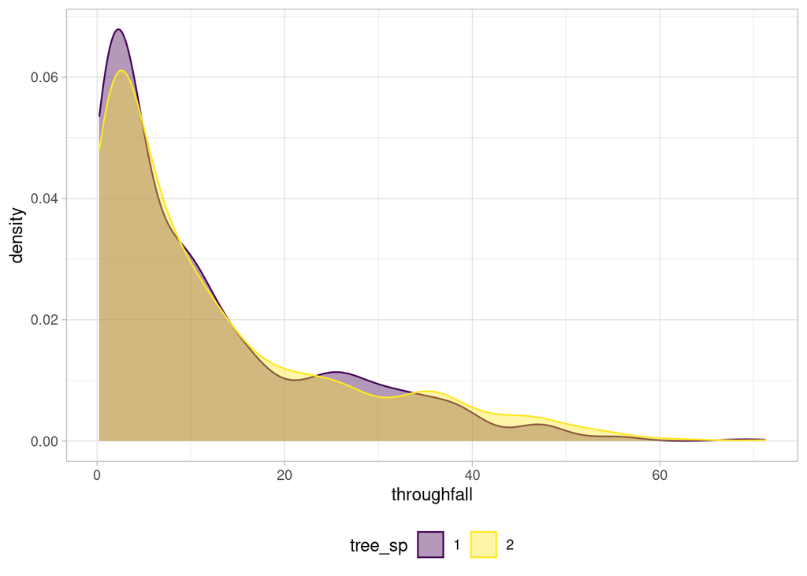

```r
dados %>%
  ggplot(aes(throughfall)) +
  geom_density(aes(color = tree_sp, fill = tree_sp), alpha = 0.4) +
  scale_fill_viridis_d() +
  scale_color_viridis_d() +
  theme(legend.position = "bottom")
```

Podemos observar que temos uma densidade maior para a espécie 1 quando estamos tratando de valores menores de throughfall enquanto a espécie 2 se sobressai na maior parte dos valores acima de 20 (maiores). Desse modo podemos supor que a espécie 2 acaba tendo um melhor desempenho tendo como objetivo uma maior quantidade de água que cai das árvores (throughfall). Além disso vemos que a densidade de ambas as espécies é extremamente similar, o que indica que podemos ter resultados próximos para throughfall independente da espécie escolhida para fazer a sombra para a plantação de café.

### Desidade da throughfall por plot

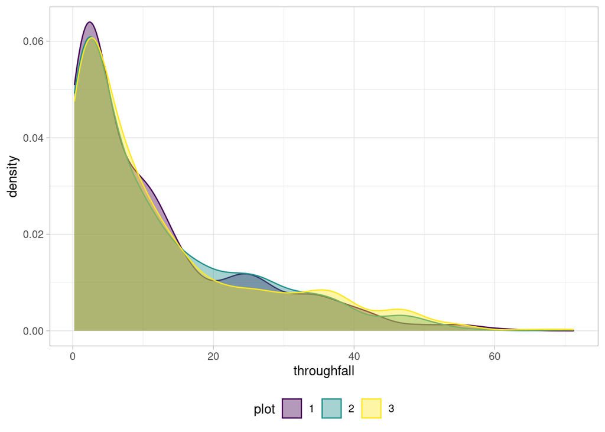

```r
dados %>%
  ggplot(aes(throughfall)) +
  geom_density(aes(color = plot, fill = plot), alpha = 0.4) +
  scale_fill_viridis_d() +
  scale_color_viridis_d() +
  theme(legend.position = "bottom")
```

Novamente podemos ver que temos densidades bastante parecidas para todos níveis da variável `plot` com o nível 1 se sobressaindo para resultados menores de throughfall, nível 2 se sobressaindo para resultados intermediários de throughfall e nível 3 apresentando maior densidade para maiores resultados de throughfall.

### Desidade da throughfall por distance

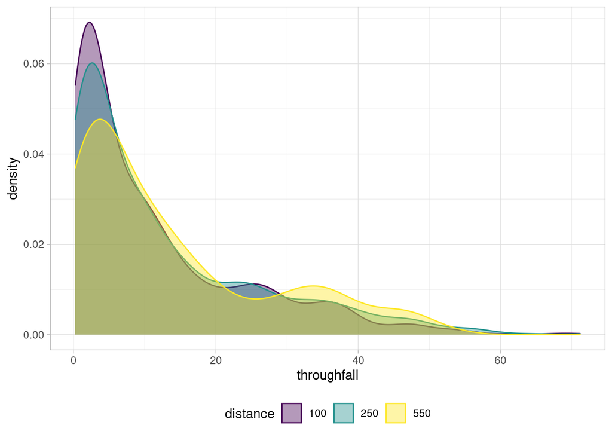

```r
dados %>%
  ggplot(aes(throughfall)) +
  geom_density(aes(color = distance, fill = distance), alpha = 0.4) +
  scale_fill_viridis_d() +
  scale_color_viridis_d() +
  theme(legend.position = "bottom")
```

No gráfico acima podemos concluir que quanto maior a distância menor a densidade para resultados pequenos (0-10) de throughfall. Além disso, a medida que esses resultados vão melhorando vemos um melhor desempenho para as distâncias maiores (250 e 550).

### Desidade da throughfall por rainfall_size

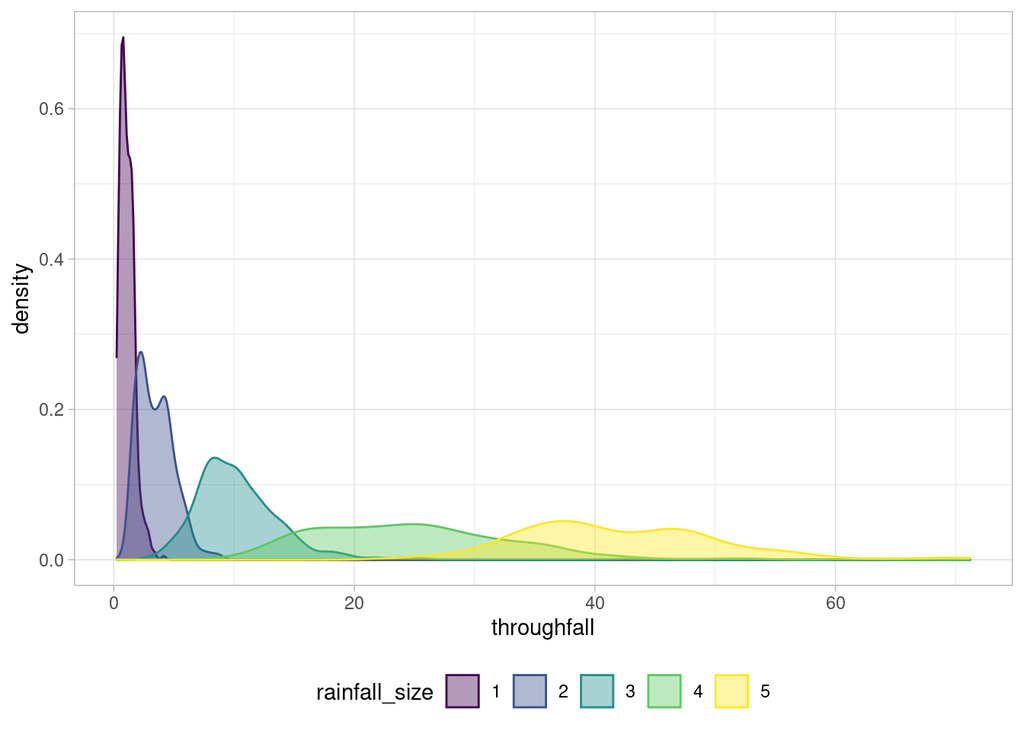

```r
dados %>%
  ggplot(aes(throughfall)) +
  geom_density(aes(color = rainfall_size, fill = rainfall_size), alpha = 0.4) +
  scale_fill_viridis_d() +
  scale_color_viridis_d() +
  theme(legend.position = "bottom")
```

Para a variável `rainfall_size` é visível que existe uma distinção clara entre os níveis possíveis, pois é fácil perceber que cada uma das categorias temos intervalos de throughfall muito bem definidos. Ademais, podemos ver que as varáveis tem uma relação direta, para níveis maiores de rainfall_size temos mariores valores de throughfall.

### Boxplot da throughfall por rainfall_size, tree_sp, plot e distance

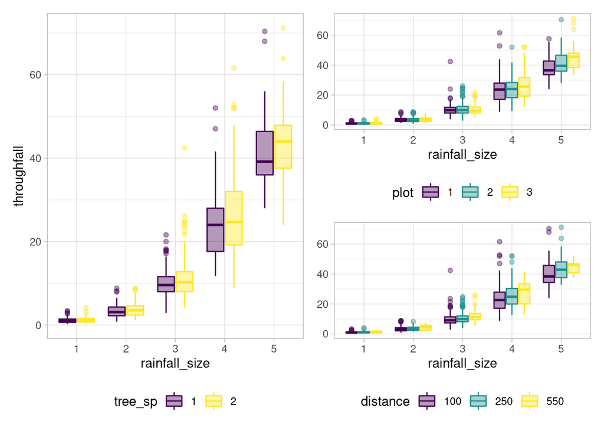

```r
p1 <- dados %>%
  ggplot(aes(rainfall_size, throughfall, color = tree_sp, fill = tree_sp)) +
  geom_boxplot(alpha = 0.4) +
  scale_fill_viridis_d() +
  scale_color_viridis_d() +
  theme(legend.position = "bottom")

p2 <- dados %>%
  ggplot(aes(rainfall_size, throughfall, color = plot, fill = plot)) +
  geom_boxplot(alpha = 0.4) +
  labs(y = NULL) +
  scale_fill_viridis_d() +
  scale_color_viridis_d() +
  theme(legend.position = "bottom")

p3 <- dados %>%
  ggplot(aes(rainfall_size, throughfall, color = distance, fill = distance)) +
  geom_boxplot(alpha = 0.4) +
  labs(y = NULL) +
  scale_fill_viridis_d() +
  scale_color_viridis_d() +
  theme(legend.position = "bottom")

p1|p2/p3
```

No gráfico acima vemos que quanto maior o nível de rainfall_size melhor os resultados de throughfall. Além disso, fica claro que as espécies para níveis menores de rainfall_size têm resultados muito similares, mostrando alguma difíveerença mais significativa para os nis de 4 e 5. Já para distance, nos níveis 3, 4 e 5 de rainfall_size vemos uma diferença entre as maiores categorias. Similarmente, temos o plot apresentando pequenas diferenças entre suas categorias para níveis 4 e 5 de rainfall_size com plot 3 sempre se sobressaindo.

### Boxplot da throughfall por plot e distance por tree_sp

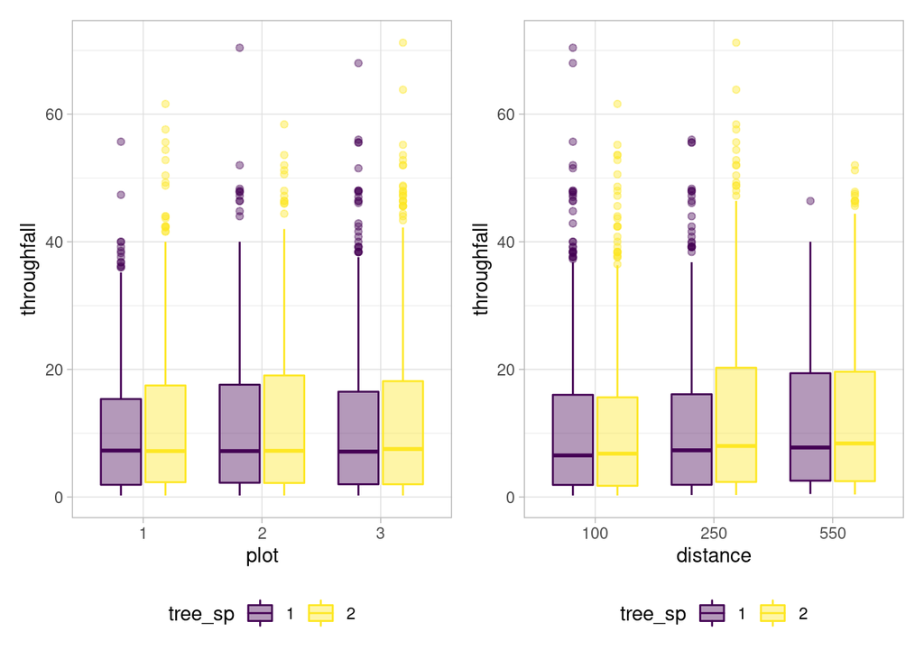

```r
p4 <- dados %>%
  ggplot(aes(plot, throughfall, color = tree_sp, fill = tree_sp)) +
  geom_boxplot(alpha = 0.4) +
  scale_fill_viridis_d() +
  scale_color_viridis_d() +
  theme(legend.position = "bottom")

p5 <- dados %>%
  ggplot(aes(distance, throughfall, color = tree_sp, fill = tree_sp)) +
  geom_boxplot(alpha = 0.4) +
  scale_fill_viridis_d() +
  scale_color_viridis_d() +
  theme(legend.position = "bottom")

p4|p5
```

Para plot podemos ver que a espécie 2 acaba tendo melhores resultados para throughfall independente do nível. Já para distance, temos uma diferença clara entre as espécies para o nível 250, uma diferença um pouco mais sutil para o nível 550 e o nível 100 sendo o único em que a espécie 1 parece apresentar um desempenho melhor, devido a uma maior frequência e maiores outliers.

### Boxplot da throughfall por plot, distance e tree_sp

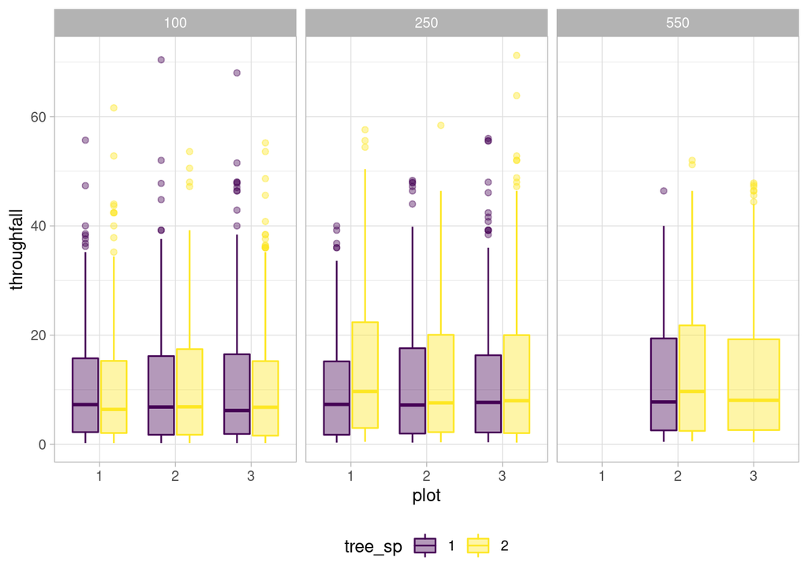

```r
dados %>%
  ggplot(aes(plot, throughfall, color = tree_sp, fill = tree_sp)) +
  geom_boxplot(alpha = 0.4) +
  facet_wrap(~distance) +
  scale_fill_viridis_d() +
  scale_color_viridis_d() +
  theme(legend.position = "bottom")
```

Inicialmente podemos notar a ausência do plot 1 na distância 550, assim como não temos a espécie 1 para plot 3 e distância 550. Além do mais, temos melhor desempenho da espécie 2 em todos os níveis de plot para distância 250 e para o plot 2 na distância 550. Para distância igual a 100 temos melhor desempenho da espécie 2 no plot 2 e nos demais níveis de plot temos a espécie 2 desempenhando de maneira inferior.

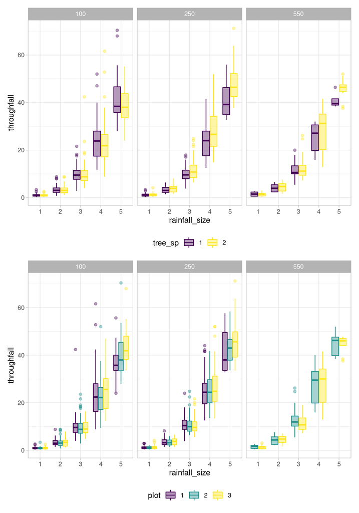

```r
p6 <- dados %>%
  ggplot(aes(rainfall_size, throughfall, color = tree_sp, fill = tree_sp)) +
  geom_boxplot(alpha = 0.4) +
  facet_wrap(~distance) +
  scale_fill_viridis_d() +
  scale_color_viridis_d() +
  theme(legend.position = "bottom")

p7 <- dados %>%
  ggplot(aes(rainfall_size, throughfall, color = plot, fill = plot)) +
  geom_boxplot(alpha = 0.4) +
  facet_wrap(~distance) +
  scale_fill_viridis_d() +
  scale_color_viridis_d() +
  theme(legend.position = "bottom")

p6/p7
```

Nos gráficos acima vemos que rainfall_size tem impacto muito forte no resultado de throughfall independente das outras variáveis que estão iteragindo com ela. No mais, para o primeiro gráfico, com exceção da distância 100, temos a espécie 2 com desempenho maior ou igual a espécie 1. No segundo gráfico, vemos que para distância 100 o plot 3 tem um desempenho melhor para altos níveis de chuva. Se focamos no níveis 4 e 5 de rainfall_size temos o plot 3 com desempenho superior aos demais principalmente por ter maior consistência em resultados altos no nível 5 de rainfall_size.

# Testes

## Anova simples

```r
aov(throughfall ~ rainfall_size, data = dados) %>% summary
```

```
##                 Df Sum Sq Mean Sq F value Pr(>F)
## rainfall_size    4 302136   75534    3257 <2e-16 ***
## Residuals     2095  48591      23
## ---
## Signif. codes:  0 '***' 0.001 '**' 0.01 '*' 0.05 '.' 0.1 ' ' 1
```

```r
aov(throughfall ~ tree_sp, data = dados) %>% summary
```

```
##               Df Sum Sq Mean Sq F value Pr(>F)
## tree_sp        1    449   448.7   2.688  0.101
## Residuals   2098 350278   167.0
```

```r
aov(throughfall ~ plot, data = dados) %>% summary
```

```
##               Df Sum Sq Mean Sq F value Pr(>F)
## plot           2    298   148.8    0.89  0.411
## Residuals   2097 350429   167.1
```

```r
aov(throughfall ~ distance, data = dados) %>% summary
```

```
##               Df Sum Sq Mean Sq F value Pr(>F)
## distance       2   1252   626.1   3.757 0.0235 *
## Residuals   2097 349474   166.7
## ---
## Signif. codes:  0 '***' 0.001 '**' 0.01 '*' 0.05 '.' 0.1 ' ' 1
```

## Anova com interação

```r
aov(throughfall ~ tree_sp*rainfall_size, data = dados) %>% summary
```

```
##                         Df Sum Sq Mean Sq  F value Pr(>F)
## tree_sp                  1    449     449   19.598  1e-05 ***
## rainfall_size            4 302136   75534 3298.946 <2e-16 ***
## tree_sp:rainfall_size    4    289      72    3.153 0.0135 *
## Residuals             2090  47853      23
## ---
## Signif. codes:  0 '***' 0.001 '**' 0.01 '*' 0.05 '.' 0.1 ' ' 1
```

```r
aov(throughfall ~ plot*rainfall_size, data = dados) %>% summary
```

```
##                      Df Sum Sq Mean Sq  F value   Pr(>F)
## plot                  2    298     149    6.559  0.00145 **
## rainfall_size         4 302136   75534 3329.724  < 2e-16 ***
## plot:rainfall_size    8    996     124    5.487 7.07e-07 ***
## Residuals          2085  47298      23
## ---
## Signif. codes:  0 '***' 0.001 '**' 0.01 '*' 0.05 '.' 0.1 ' ' 1
```

```r
aov(throughfall ~ distance*rainfall_size, data = dados) %>% summary
```

```
##                          Df Sum Sq Mean Sq  F value   Pr(>F)
## distance                  2   1252     626   28.059 9.45e-13 ***
## rainfall_size             4 302136   75534 3385.252  < 2e-16 ***
## distance:rainfall_size    8    817     102    4.577 1.52e-05 ***
## Residuals              2085  46522      22
## ---
## Signif. codes:  0 '***' 0.001 '**' 0.01 '*' 0.05 '.' 0.1 ' ' 1
```

```r
aov(throughfall ~ tree_sp*plot, data = dados) %>% summary
```

```
##                Df Sum Sq Mean Sq F value Pr(>F)
## tree_sp         1    449   448.7   2.685  0.101
## plot            2    219   109.4   0.655  0.520
## tree_sp:plot    2    116    57.9   0.346  0.707
## Residuals    2094 349943   167.1
```

```r
aov(throughfall ~ tree_sp*distance, data = dados) %>% summary
```

```
##                    Df Sum Sq Mean Sq F value Pr(>F)
## tree_sp             1    449   448.7   2.696  0.101
## distance            2   1128   563.8   3.388  0.034 *
## tree_sp:distance    2    672   336.0   2.019  0.133
## Residuals        2094 348478   166.4
## ---
## Signif. codes:  0 '***' 0.001 '**' 0.01 '*' 0.05 '.' 0.1 ' ' 1
```

```r
aov(throughfall ~ plot*rainfall_size*distance, data = dados) %>% summary
```

```
##                               Df Sum Sq Mean Sq  F value   Pr(>F)
## plot                           2    298     149    6.753  0.00119 **
## rainfall_size                  4 302136   75534 3428.400  < 2e-16 ***
## distance                       2   1087     544   24.677 2.57e-11 ***
## plot:rainfall_size             8    996     124    5.649 4.07e-07 ***
## plot:distance                  3     51      17    0.779  0.50587
## rainfall_size:distance         8    671      84    3.804  0.00019 ***
## plot:rainfall_size:distance   12    103       9    0.389  0.96812
## Residuals                   2060  45386      22
## ---
## Signif. codes:  0 '***' 0.001 '**' 0.01 '*' 0.05 '.' 0.1 ' ' 1
```

```r
aov(throughfall ~ tree_sp*plot*distance, data = dados) %>% summary
```

```
##                         Df Sum Sq Mean Sq F value Pr(>F)
## tree_sp                  1    449   448.7   2.692 0.1010
## plot                     2    219   109.4   0.656 0.5189
## distance                 2   1002   501.0   3.005 0.0497 *
## tree_sp:plot             2    238   119.0   0.714 0.4898
## tree_sp:distance         2    725   362.4   2.174 0.1140
## plot:distance            3    129    43.0   0.258 0.8557
## tree_sp:plot:distance    2    352   176.0   1.056 0.3481
## Residuals             2085 347613   166.7
## ---
## Signif. codes:  0 '***' 0.001 '**' 0.01 '*' 0.05 '.' 0.1 ' ' 1
```

```r
aov(throughfall ~ tree_sp*rainfall_size*distance, data = dados) %>% summary
```

```
##                                  Df Sum Sq Mean Sq  F value   Pr(>F)
## tree_sp                           1    449     449   20.954 4.98e-06 ***
## rainfall_size                     4 302136   75534 3527.217  < 2e-16 ***
## distance                          2   1128     564   26.329 5.11e-12 ***
## tree_sp:rainfall_size             4    289      72    3.371  0.00929 **
## tree_sp:distance                  2    672     336   15.689 1.73e-07 ***
## rainfall_size:distance            8    771      96    4.503 1.94e-05 ***
## tree_sp:rainfall_size:distance    8    954     119    5.570 5.33e-07 ***
## Residuals                      2070  44328      21
## ---
## Signif. codes:  0 '***' 0.001 '**' 0.01 '*' 0.05 '.' 0.1 ' ' 1
```

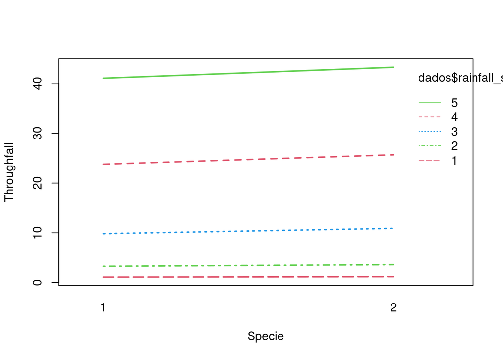

```r
interaction.plot(dados$tree_sp, dados$rainfall_size, dados$throughfall, legend=T, col=2:4, lwd=2, xlab = "Specie", ylab = "Throughfall")
```

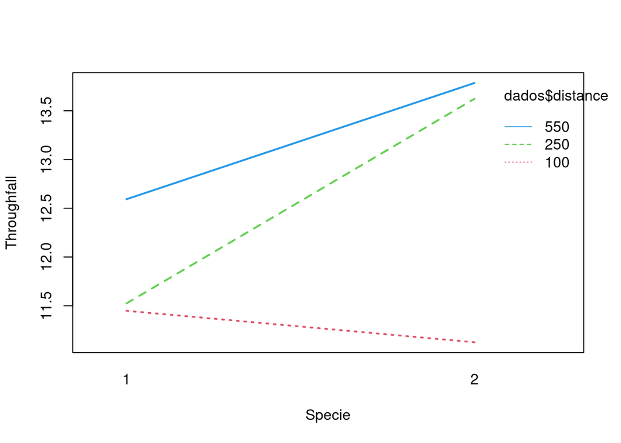

```r
interaction.plot(dados$tree_sp, dados$distance, dados$throughfall, legend=T, col=2:4, lwd=2, xlab = "Specie", ylab = "Throughfall")
```

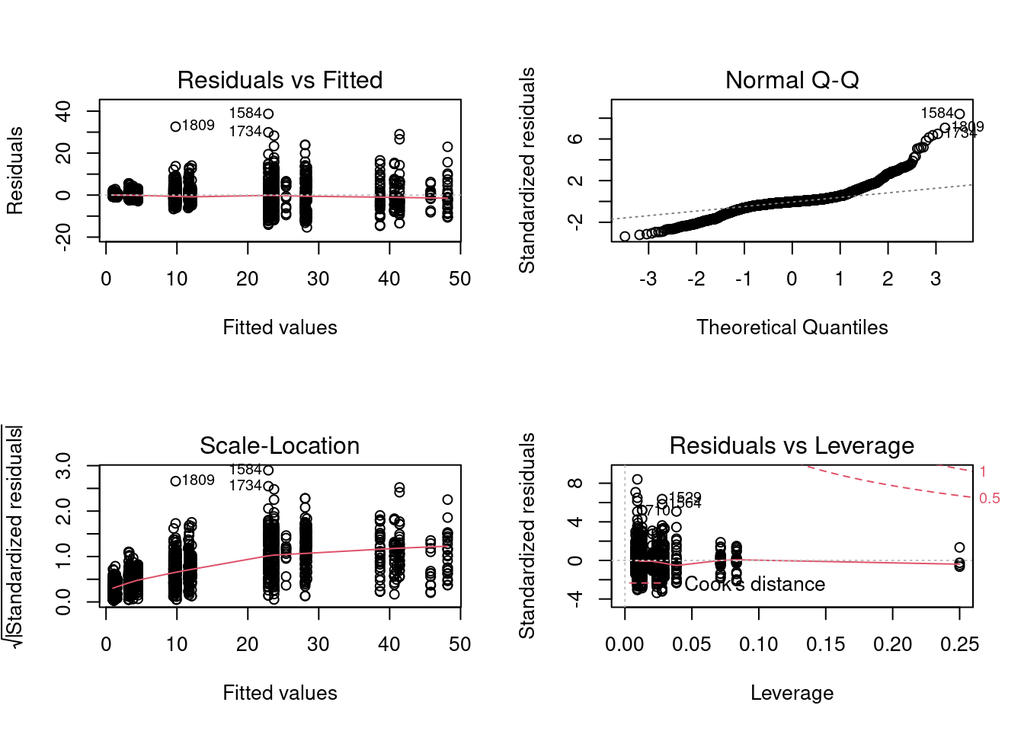

```r
fit <- aov(throughfall ~ tree_sp*rainfall_size*distance, data = dados)
par(mfrow = c(2, 2))
plot(fit)
```

```r
fit_lsmeans <- lsmeans::lsmeans(fit, ~tree_sp|(rainfall_size*distance))
pairs(fit_lsmeans)
```

```
## rainfall_size = 1, distance = 100:
##  contrast estimate    SE   df t.ratio p.value
##  1 - 2     0.00296 0.630 2070   0.005  0.9962
##
## rainfall_size = 2, distance = 100:
##  contrast estimate    SE   df t.ratio p.value
##  1 - 2     0.10095 0.583 2070   0.173  0.8625
##
## rainfall_size = 3, distance = 100:
##  contrast estimate    SE   df t.ratio p.value
##  1 - 2    -0.28381 0.583 2070  -0.487  0.6265
##
## rainfall_size = 4, distance = 100:
##  contrast estimate    SE   df t.ratio p.value
##  1 - 2     0.79926 0.630 2070   1.269  0.2045
##
## rainfall_size = 5, distance = 100:
##  contrast estimate    SE   df t.ratio p.value
##  1 - 2     2.75139 1.091 2070   2.523  0.0117
##
## rainfall_size = 1, distance = 250:
##  contrast estimate    SE   df t.ratio p.value
##  1 - 2    -0.18932 0.696 2070  -0.272  0.7857
##
## rainfall_size = 2, distance = 250:
##  contrast estimate    SE   df t.ratio p.value
##  1 - 2    -0.54798 0.644 2070  -0.850  0.3952
##
## rainfall_size = 3, distance = 250:
##  contrast estimate    SE   df t.ratio p.value
##  1 - 2    -1.78480 0.644 2070  -2.770  0.0057
##
## rainfall_size = 4, distance = 250:
##  contrast estimate    SE   df t.ratio p.value
##  1 - 2    -4.37906 0.696 2070  -6.291  <.0001
##
## rainfall_size = 5, distance = 250:
##  contrast estimate    SE   df t.ratio p.value
##  1 - 2    -7.50480 1.206 2070  -6.225  <.0001
##
## rainfall_size = 1, distance = 550:
##  contrast estimate    SE   df t.ratio p.value
##  1 - 2     0.17905 1.515 2070   0.118  0.9059
##
## rainfall_size = 2, distance = 550:
##  contrast estimate    SE   df t.ratio p.value
##  1 - 2    -0.54694 1.402 2070  -0.390  0.6966
##
## rainfall_size = 3, distance = 550:
##  contrast estimate    SE   df t.ratio p.value
##  1 - 2    -0.48408 1.402 2070  -0.345  0.7300
##
## rainfall_size = 4, distance = 550:
##  contrast estimate    SE   df t.ratio p.value
##  1 - 2    -2.93810 1.515 2070  -1.940  0.0526
##
## rainfall_size = 5, distance = 550:
##  contrast estimate    SE   df t.ratio p.value
##  1 - 2    -4.80286 2.624 2070  -1.831  0.0673
```

```r
(fit_tukey<-TukeyHSD(fit, "tree_sp:rainfall_size:distance"))
```

```
##   Tukey multiple comparisons of means
##     95% family-wise confidence level
##
## Fit: aov(formula = throughfall ~ tree_sp * rainfall_size * distance, data = dados)
##
## $`tree_sp:rainfall_size:distance`
##                          diff          lwr         upr     p adj
## 2:1:100-1:1:100  -0.002962963  -2.36698556   2.3610596 1.0000000
## 1:2:100-1:1:100   2.310476190   0.03244702   4.5885054 0.0416337
## 2:2:100-1:1:100   2.209523810  -0.06850536   4.4875530 0.0724905
## 1:3:100-1:1:100   8.552380952   6.27435178  10.8304101 0.0000000
## 2:3:100-1:1:100   8.836190476   6.55816130  11.1142196 0.0000000
## 1:4:100-1:1:100  22.716296296  20.35227370  25.0803189 0.0000000
## 2:4:100-1:1:100  21.917037037  19.55301444  24.2810596 0.0000000
## 1:5:100-1:1:100  40.418055556  37.07482274  43.7612884 0.0000000
## 2:5:100-1:1:100  37.666666667  34.32343385  41.0098995 0.0000000
## 1:1:250-1:1:100   0.137516340  -2.26101936   2.5360520 1.0000000
## 2:1:250-1:1:100   0.326837607  -2.25450587   2.9081811 1.0000000
## 1:2:250-1:1:100   2.293146592  -0.01559897   4.6018922 0.0544503
## 2:2:250-1:1:100   2.841123321   0.36915747   5.3130892 0.0059398
## 1:3:250-1:1:100   8.955667600   6.64692204  11.2644132 0.0000000
## 2:3:250-1:1:100  10.740463980   8.26849813  13.2124298 0.0000000
## 1:4:250-1:1:100  22.724183007  20.32564731  25.1227187 0.0000000
## 2:4:250-1:1:100  27.103247863  24.52190439  29.6845913 0.0000000
## 1:5:250-1:1:100  39.692810458  36.27662579  43.1089951 0.0000000
## 2:5:250-1:1:100  47.197606838  43.40268924  50.9925244 0.0000000
## 1:1:550-1:1:100   0.595555556  -4.69055967   5.8816708 1.0000000
## 2:1:550-1:1:100   0.416507937  -2.74255014   3.5755660 1.0000000
## 1:2:550-1:1:100   2.976507937  -1.95809852   7.9111144 0.9095683
## 2:2:550-1:1:100   3.523446712   0.53126192   6.5156315 0.0037834
## 1:3:550-1:1:100  10.616507937   5.68190148  15.5511144 0.0000000
## 2:3:550-1:1:100  11.100589569   8.10840478  14.0927744 0.0000000
## 1:4:550-1:1:100  24.415555556  19.12944033  29.7016708 0.0000000
## 2:4:550-1:1:100  27.353650794  24.19459272  30.5127089 0.0000000
## 1:5:550-1:1:100  40.002222222  31.15685962  48.8475848 0.0000000
## 2:5:550-1:1:100  44.805079365  39.87047291  49.7396858 0.0000000
## 1:2:100-2:1:100   2.313439153   0.03540998   4.5914683 0.0409341
## 2:2:100-2:1:100   2.212486772  -0.06554240   4.4905159 0.0713664
## 1:3:100-2:1:100   8.555343915   6.27731474  10.8333731 0.0000000
## 2:3:100-2:1:100   8.839153439   6.56112427  11.1171826 0.0000000
```

[output cut: 387 more lines]

```
## 2:3:550-1:3:550   0.484081633  -4.78041340   5.7485767 1.0000000
## 1:4:550-1:3:550  13.799047619   6.96496010  20.6331351 0.0000000
## 2:4:550-1:3:550  16.737142857  11.37604353  22.0982422 0.0000000
## 1:5:550-1:3:550  29.385714286  19.53674593  39.2346826 0.0000000
## 2:5:550-1:3:550  34.188571429  27.62259253  40.7545503 0.0000000
## 1:4:550-2:3:550  13.314965986   7.71964820  18.9102838 0.0000000
## 2:4:550-2:3:550  16.253061224  12.60008779  19.9060347 0.0000000
## 1:5:550-2:3:550  28.901632653  19.86808371  37.9351816 0.0000000
## 2:5:550-2:3:550  33.704489796  28.43999477  38.9689848 0.0000000
## 2:4:550-1:4:550   2.938095238  -2.74820929   8.6243998 0.9859020
## 1:5:550-1:4:550  15.586666667   5.55696822  25.6163651 0.0000027
## 2:5:550-1:4:550  20.389523810  13.55543629  27.2236113 0.0000000
## 1:5:550-2:4:550  12.648571429   3.55838526  21.7387576 0.0000801
## 2:5:550-2:4:550  17.451428571  12.09032925  22.8125279 0.0000000
## 2:5:550-1:5:550   4.802857143  -5.04611121  14.6518255 0.9938886
```

```r
fit_plot <- aov(throughfall ~ tree_sp/(rainfall_size*distance), data = dados)
```

```r
summary(fit_plot, split=list("tree_sp:rainfall_size" = list("tree_sp1"= grep("tree_sp1", names(coef(fit_plot)[3:10])), "tree_sp2"= grep("tree_sp2", names(coef(fit_plot)[3:10]))), "tree_sp:distance" = list("tree_sp1"= grep("tree_sp1", names(coef(fit_plot)[11:14])), "tree_sp2"= grep("tree_sp2", names(coef(fit_plot)[11:14])))))
```

```
##                                     Df Sum Sq Mean Sq  F value   Pr(>F)
## tree_sp                              1    449     449   20.954 4.98e-06 ***
## tree_sp:rainfall_size                8 302424   37803 1765.294  < 2e-16 ***
##   tree_sp:rainfall_size: tree_sp1    4 140308   35077 1637.991  < 2e-16 ***
##   tree_sp:rainfall_size: tree_sp2    4 162117   40529 1892.597  < 2e-16 ***
## tree_sp:distance                     4   1800     450   21.009  < 2e-16 ***
##   tree_sp:distance: tree_sp1         2     66      33    1.551    0.212
##   tree_sp:distance: tree_sp2         2   1733     867   40.468  < 2e-16 ***
## tree_sp:rainfall_size:distance      16   1726     108    5.036 2.21e-10 ***
## Residuals                         2070  44328      21
## ---
## Signif. codes:  0 '***' 0.001 '**' 0.01 '*' 0.05 '.' 0.1 ' ' 1
```